# RR Course Project 1

Me

2022-10-29

# PROJECT

## 1. Loading and preprocessing the data

`Activity \<- read.csv("C:/Users/diken/Έγγραφα/R/repdata_data_activity/activity.csv")`

## 2. What is mean total number of steps taken per day?

### I. Calculate the total number of steps taken per day

`nona <- na.omit(Activity)`

`SMean <- aggregate(steps~date, nona, sum)`

### II. Make a histogram of the total number of steps taken each day

`library(ggplot2)`

`ggplot(data=SMean, aes(steps)) + geom_histogram(binwidth=400, fill="blue", col="black") + labs(main="Histogram: Total number of steps per day", x="Total number of steps per day")`

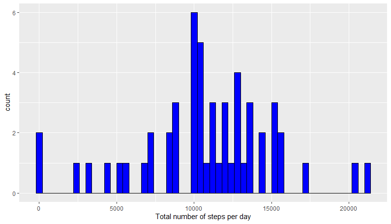

Rplot1

## 3. What is the average daily activity pattern?

### I. Make a time series plot (i.e. type = “l”) of the 5-minute interval (x-axis) and the average number of steps taken, averaged across all days (y-axis)

`SIMean <- aggregate(steps~interval, nona, mean)`

`ggplot(data=SIMean, aes(x=interval,y=steps)) + geom_line() + labs(title="Average number of steps taken", x="interval (1 interval = 5 minutes)")`

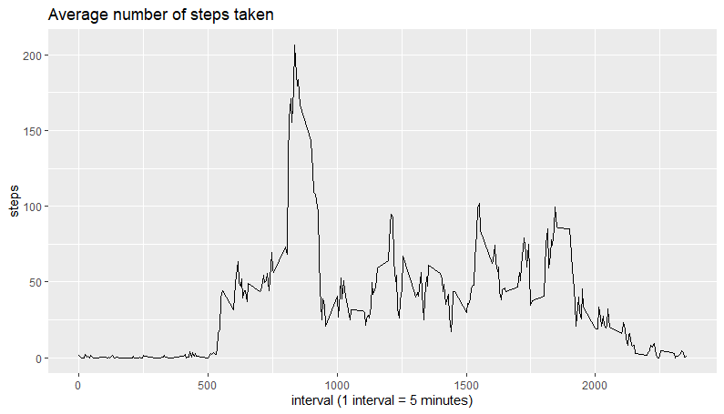

Rplot2

## 4. Imputing missing values

### II. Devise a strategy for filling in all of the missing values in the dataset. The strategy does not need to be sophisticated. For example, you could use the mean/median for that day, or the mean for that 5-minute interval, etc.

### III. Create a new dataset that is equal to the original dataset but with the missing data filled in.

`ActivityFull <- Activity`

`ActivityFull$steps <- ifelse(is.na(ActivityFull$steps) == TRUE, SIMean$steps[SIMean$interval %in%ActivityFull$interval], ActivityFull$steps)`

`ActivityFullDate <- aggregate(steps~date, ActivityFull, sum)`

`p1 <- ggplot(data=SMean, aes(steps)) + geom_histogram(binwidth=400, fill="blue", col="black") + labs(x=NULL,y=NULL) + ylim(c(0,12.5))`

`p2 <- ggplot(data=ActivityFullDate, aes(steps)) + geom_histogram(binwidth=400, fill="yellow", col="black") + labs(x=NULL,y=NULL) + ylim(c(0,12.5))`

`library(ggpubr)`

`p1_p2 <- ggarrange(p1, p2, labels = c("Removed NA data", "Filled NA data"), ncol = 2, nrow = 1, font.label=list(size=12, face="plain"))`

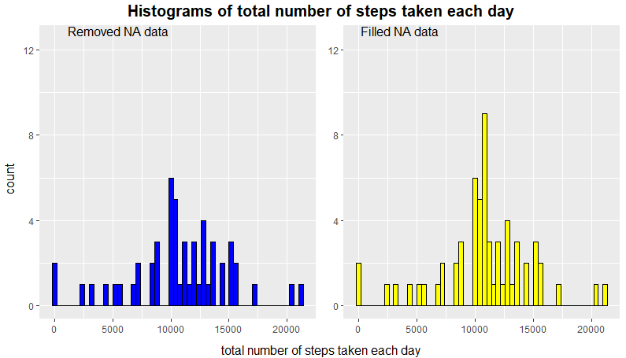

Rplot3

`annotate_figure(p1_p2, top = text_grob("Histograms of total number of steps taken each day", face="bold", size=15), bottom = text_grob("total number of steps taken each day"), left = text_grob("count", rot=90))`

`rm(p1,p2,p1_p2)`

`t1 <- summary(SMean)`

`t2 <- summary(ActivityFullDate)`

## 5. Are there differences in activity patterns between weekdays and weekends?

### I. Create a new factor variable in the dataset with two levels – “weekday” and “weekend” indicating whether a given date is a weekday or weekend day.

`AWeek <- ActivityFull`

`AWeek$day <- as.factor(weekdays(as.Date(AWeek$date)))`

`AWeek$WD_WE <- as.factor(ifelse(AWeek$day == "Saturday" | AWeek$day == "Sunday", "weekend", "weekday"))`

### II. Make a panel plot containing a time series plot (i.e.type = “l”) of the 5-minute interval (x-axis) and the average number of steps taken, averaged across all weekday days or weekend days (y-axis). See the README file in the GitHub repository to see an example of what this plot should look like using simulated data.

`awd <- aggregate(steps ~ interval + WD_WE, AWeek, mean)`

`ggplot(data=awd, aes(colour=WD_WE, x=interval, y=steps)) + geom_line()+labs(x="interval (1 interval = 5 minutes)", y="steps", title="Average number of steps taken on weekdays/weekend") + facet_grid(WD_WE ~ .)`

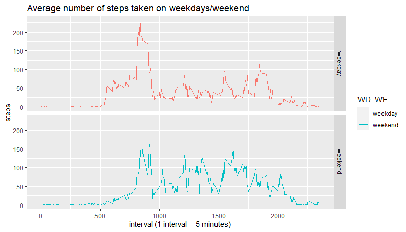

Rplot4